# PS3: Control Flow and Functions

STAT 133

**NoteGeneral Instructions**

- Use the template file `ps3.qmd` to answer the questions.
- Rename `ps3.qmd` to `ps3-first-last.qmd`, where `first` and `last` are your first and last names (e.g. `ps3-gaston-sanchez.qmd`).
- Submit both your qmd and HTML files to the corresponding assignment submission in bCourses.

# 1 Pythagoras

The Pythagoras formula is used to compute the length of the hypotenuse, $c$, of a right triangle with legs of length $a$ and $b$.

$$c = \sqrt{a^2 + b^2}$$

## 1.1 `pythagoras()` version 1

Write a function `pythagoras()` that takes two arguments `a` and `b`, and returns the length of the hypotenuse.

```r
# write your pythagoras function here
pythagoras <- function(a, b) {
  c <- sqrt(a^2 + b^2)
  return(c)
}
```

Now, add roxygen comments to document your function.

```r
# paste your function here and add roxygen comments
#' @title Pythagoras Formula
#' @description Calculates the hypotenuse of a right triangle
#' @param a length of the first leg
#' @param b length of the second leg
#' @return length of the hypotenuse
pythagoras <- function(a, b) {
  c <- sqrt(a^2 + b^2)
  return(c)
}
```

Test your `pythagoras()` with two leg values: e.g. `pythagoras(3, 4)`.

```r
# call your function here
pythagoras(3, 4)
```

```
[1] 5
```

## 1.2 `pythagoras()` version 2

Modify your function `pythagoras()` so that argument `b` takes the same value of argument `a` by default. *Your function should still allow two inputs!*

```r
# your modified pythagoras function here
pythagoras <- function(a, b = a) {
  c <- sqrt(a^2 + b^2)
  return(c)
}
```

Test it with just one leg value: e.g. `pythagoras(5)`.

```r
# call your function here
pythagoras(5)
```

```
[1] 7.071068
```

# 2 Gaussian Function

The Gaussian (Normal) function, given in the equation below, is one of the most widely used functions in science and statistics:

$$g(x) = \frac{1}{\sigma \sqrt{2 \pi}} \ \exp \left [ - \frac{1}{2} \left (\frac{x - \mu}{\sigma} \right )^2 \right ]$$

The parameters $\sigma$ and $\mu$ are real numbers, where $\sigma$ must be greater than zero. For more information, see the wikipedia entry: [Normal Distribution](https://en.wikipedia.org/wiki/Normal_distribution#)

## 2.1 Function `gaussian()`

- Make a function `gaussian()` that takes three arguments: `x`, `mu`, and `sigma` and evaluates the expression above.
- Use `exp()` for the exponential part.

```r
# write your function here
gaussian <- function(x, mu, sigma) {
  return((1 / (sigma * sqrt(2 * pi))) * (exp(-0.5 * ((x - mu) / sigma)^2)))
}
```

Modify your function so that it raises an error message if `sigma` is not positive.

```r
# copy your function and add the error functionality
gaussian <- function(x, mu, sigma) {
  if (sigma <= 0) {
    stop("Error! sigma must be a positive number!")
  }
  return((1 / (sigma * sqrt(2 * pi))) * (exp(-0.5 * ((x - mu) / sigma)^2)))
}
```

Evaluate the function with `mu = 0`, `sigma = 2`, and `x = 1`.

```r
# call your function here
gaussian(1, 0, 2)
```

```
[1] 0.1760327
```

## 2.2 Graphing a Normal curve

Once you have your `gaussian()` function try it with a vector `x = seq(-6, 6, by = 0.1)`, and pass the `x` and outputs to `plot()` to get a normal curve.

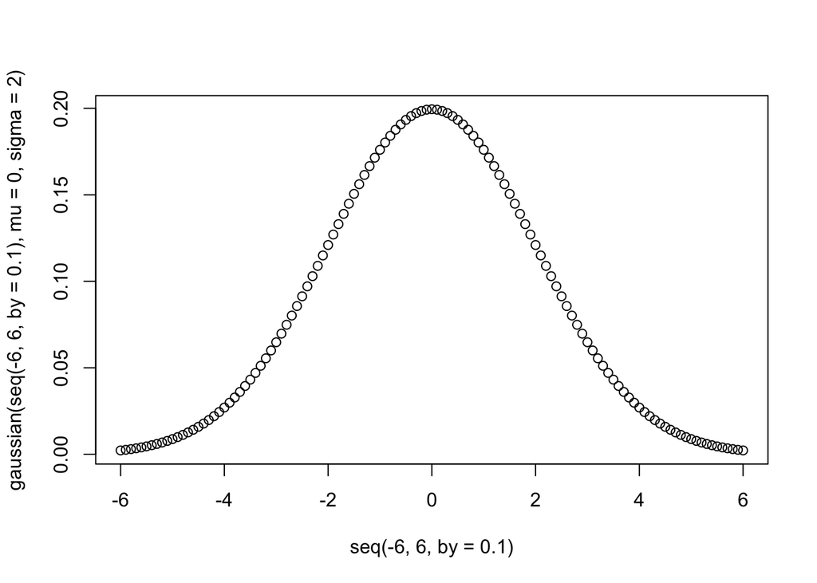

```r
# plot function here
plot(seq(-6, 6, by = 0.1), gaussian(seq(-6, 6, by = 0.1), mu = 0, sigma = 2))
```

## 2.3 Compare to `d(norm)`

R actually has a built-in function to calculate the density of a normal distribution. Type `help(dnorm)` in the R *console* to learn more about this function. Compare your function to the built-in `dbinom`. Notice that `dnorm` has an additional input when compared to our `gaussian` function. Describe this input. What type of object does it take? How does it affect the output of the function?

**TipType your answer in this callout block:**

The additional input is log. It takes a logical (boolean) object (TRUE or FALSE). If set to TRUE, the function returns the log-density instead of the density.

Call `dbinom` with the inputs `x=1`, `mean = 0`, and `sd = 2`and check that it returns the same output as your `gaussian` function.

```r
# call dnorm here
dnorm(x = 1, mean = 0, sd = 2)
```

```
[1] 0.1760327
```

# 3 Population in Logistic Growth

Consider the following formula for computing the population size at time t according to a logistic growth model:

$$P(t) = \frac{K}{1 + \left(\frac{K - P_0}{P_0}\right)e^{-rt}}$$

where:

- $K$ = carrying capacity of the environment
- $P_0$ = initial population
- $r$ = intrinsic growth rate
- $t$ = time (we will use years)

## 3.1 Function `logistic_growth()`

Create a function `logistic_growth()` that allows you to compute the population at time ($t$) using the Logistic Growth model.

- Use the formula of the above equation to write a function `logistic_growth()`.
- Give descriptive names to the arguments of the function.
- Also, give default values to the arguments.
- Don’t forget to include documentation comments (title, description, inputs, and output).

```r
# write your function here
#' @title Logistic Growth Model
#' @description Computes population size at time t
#' @param t time in years (default 1)
#' @param K carrying capacity (default 1000)
#' @param P0 initial population (default 100)
#' @param r intrinsic growth rate (default 0.1)
#' @return numerical value of population at time t
logistic_growth <- function(t = 1, K = 1000, P0 = 100, r = 0.1) {
  return(K / (1 + ((K - P0) / P0) * exp(-r * t)))
}
```

## 3.2 Use `logistic_growth()` to answer the following questions

1. Suppose a population of bacteria starts with an initial population of $P_0 = 100$ individuals and has a carrying capacity of $K = 5000$. If the intrinsic growth rate is $r = 0.4$, what will the population be after $10$ years?

```r
# call your function here
logistic_growth(t = 10, K = 5000, P0 = 100, r = 0.4)
```

[output not shown]

2. A wildlife reserve introduces $250$ deer into an environment with a carrying capacity of $2000$ deer. Assume the intrinsic growth rate is $0.25$. What is the population size after $15$ years?

```r
# call your function here
logistic_growth(t = 15, K = 2000, P0 = 250, r = 0.25)
```

[output not shown]

3. Consider the previous part (b); but now assume different possible growth rates $r = 0.15, 0.25, 0.35$. Pass a vector of growth rates to your function `logistic_growth()` and obtain the three different population values after 15 time units.

```r
# call your function here
r <- c(0.15, 0.25, 0.35)
logistic_growth(t = 15, K = 2000, P0 = 250, r = r)
```

[output not shown]

# 4 Binomial Probability

The formula for the binomial probability is:

$$Prob(X = k) = {n \choose k} p^k (1-p)^{n-k}$$

where:

- $n$ is the number of (fixed) trials
- $p$ is the probability of success in each trial
- $1 - p$ is the probability of failure in each trial
- $k$ is a variable that represents the number of successes out of $n$ trials
- the first term in parenthesis is **not** a fraction, it is the number of combinations in which $k$ success can occur in $n$ trials

R provides the `choose()` function to compute the number of combinations:

$${n \choose k} = \frac{n (n-1) \cdots (n - k +1)}{k (k-1) \cdots 1}$$

For instance, the number of combinations in which $k$ = 2 success can occur in $n$ = 5 trials is:

```r
choose(n = 5, k = 2)
```

```
[1] 10
```

## 4.1 Function `bin_probability`

Write a function `bin_probability` that returns the binomial probability. This function should take the following arguments:

- `n`: number of trials
- `k`: number of successes
- `p:` probability of success (in a single trial)

Likewise, `bin_probability()` should `stop()` in the following cases:

- `n < 1` (there has to be at least one trial)
- when `k > n` (cannot have more successes than trials)
- when `p < 0` or `p > 1` (probability `p` must be between 0 and 1)

And don’t forget to include documentation comments (title, description, inputs, and output)!

```r
# write your function here
#' @title Binomial Probability
#' @description Calculates the probability of k successes in n trials
#' @param n number of trials
#' @param k number of successes
#' @param p probability of success
#' @return probability value
bin_probability <- function(n, k, p) {
  if (n < 1) stop("n must be at least 1")
  if (k > n) stop("k cannot be greater than n")
  if (p < 0 | p > 1) stop("p must be between 0 and 1")
  return(choose(n, k) * (p^k) * (1 - p)^(n - k))
}
```

Use your `bin_probability()` function to obtain:

1. the probability of getting 2 heads in 5 tosses of a (fair) coin
   - $n = 5$ trials
   - $k = 2$ successes
   - $p = 1/2$ probability of success (getting heads)

```r
# call your function here
bin_probability(n = 5, k = 2, p = 0.5)
```

```
[1] 0.3125
```

2. the probability of getting 3 sixes in 3 rolls of a (fair) die
   - $n = 3$ trials
   - $k = 3$ successes
   - $p = 1/6$ probability of success (getting a six)

```r
# call your function here
bin_probability(n = 3, k = 3, p = 1/6)
```

```
[1] 0.00462963
```

## 4.2 Function `bin_tail`

Your function above calculates $Prob(X = k)$. The lower tail probability for a binomial is the $Prob (X\leq k)$ and is calculated by summing (adding) the individual probabilites from $0$ to $k$. For example,

$$Prob(X\leq 2) = Prob(X = 0) + Prob(X = 1) + Prob(X = 2)$$

Replace the blanks below to write a new function `bin_tail` that uses the function `bin_prob` to calculate the tail probability $P(X \leq k)$. (Hint:`seq()` will be useful here.)

```r
# ignore the "eval:false" that appears in the qmd template
# and replace the blanks to complete the function below
bin_tail <- function(n, k, p){
  s <- 0
  for(i in 0:k){
    s <- s + bin_probability(n, i, p)
  }
  return(s)
}
```